# Merging Data and Statistical Relationships

Week 5

Published

October 17, 2025

# Before we start

- Any questions?

[Download script](https://artur-baranov.github.io/nu-ps403-ds/scripts/ps403-d_05.qmd)

[Download data](https://artur-baranov.github.io/nu-ps403-ds/data/WHR.csv)

**Review**

First, load the `tidyverse` library

```r
library(tidyverse)
```

Load the WhoGov dataset.

```r
whogov = read.csv("data/WhoGov.csv")
```

First of all, **data wrangling** (*take a look on week 2 script*).

Create a variable for independent and partisan leaders using `case_when()`.

```r
whogov = whogov %>%
  mutate(indep = ...(leader_party ... "independent" ... "Independent",
                     leader_party != ... "Partisan"))
```

Check the distribution of the newly created variable using `table()`

```r
...
```

Now, **visualizations**. Draw a histogram of `average_total`. Add an average. Make sure to name X axis: “Average Tenure of People in cabinet”.

```r
...
```

Now, draw a boxplot. X axis is `indep`, and Y axis is `average_total`.

```r
whogov_boxplot = ...

whogov_boxplot
```

Add a `facet_wrap(~ system_category)`. And add `coord_flip()`. How is it different from `facet_grid()` we used last time?

```r
whogov_boxplot ...
```

# Agenda

- Learning how to merge data
- Comparing distributions, *statistically*

# Data Exploration

Today we are working with World Happiness report and V-Dem. Here are respective codebooks: [WHR](https://web.archive.org/web/20241211202813/https://happiness-report.s3.amazonaws.com/2024/Ch2+Appendix.pdf) and [V-Dem](https://v-dem.net/documents/38/V-Dem_Codebook_v14.pdf).

Let’s start with WHS.

- `Country_name` is the name of the country
- `Ladder_score` is the happiness score

Load the data.

```r
whr = read.csv("data/WHR.csv")
```

Now, load the V-Dem data.

- `country_name` is the name of the country
- `year` is the year of observation
- `e_v2x_api_3C` is Additive polyarchy index ordinal (*what is polyarchy?*)

I have filtered out only the variables we need to work with today.

```r
load(url("https://github.com/vdeminstitute/vdemdata/raw/6bee8e170578fe8ccdc1414ae239c5e870996bc0/data/vdem.RData"))

vdem = vdem %>%
  select(country_name,
         year,
         regime = e_v2x_api_3C)
```

Imagine, we are asked: are democracies happier than non-democracies?

# Joining Data

We can start exploring this relationship with our skilleset! But we need to add one more: joining or merging the data.

To merge the data, we need to choose a variable that is common to both datasets. In our case, it’s the **country names**. Often, you would also have a year variable—but since our WHR report data is for the year 2022, let’s subset the V-Dem data to include only observations from 2022. Once again, why are we using`==`?

```r
vdem_2022 = vdem %>%
  filter(year == 2022)
```

Now, let’s merge the data using `left_join()`. Pay attention to the syntax, especially the `by` part.

```r
whr_vdem = whr %>%
  left_join(vdem_2022, by = c("Country_name" = "country_name"))
```

Check the result.

```r
whr_vdem = whr_vdem %>%
  select(Country_name, Ladder_score, regime)

whr_vdem %>%
  head()
```

```
  Country_name Ladder_score regime
1      Finland        7.804      1
2      Denmark        7.586      1
3      Iceland        7.530      1
4       Israel        7.473      1
5  Netherlands        7.403      1
6       Sweden        7.395      1
```

This is what we did, feel free to explore the [tutorial](https://rpubs.com/williamsurles/293454).

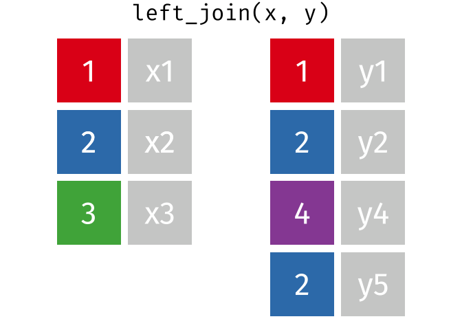

# Comparing Distributions

Comparing two groups is a bit easier, as things quickly get messier when you have more. Let’s start with that. Create a binary variable in the dataset that would indicate if a country is a Democracy or Autocracy. You know how to use this `case_when()` function already, right?

```r
whr_vdem = whr_vdem %>%
  mutate(regime_categorical = case_when(regime != 1 ~ "Autocratic",
                                        regime == 1 ~ "Democratic"))
```

Let’s start exploring patterns. What are the top 5 happiest countries? Are these democracies?

```r
whr_vdem %>%
  slice_max(Ladder_score, n = 5)
```

```
  Country_name Ladder_score regime regime_categorical
1      Finland        7.804      1         Democratic
2      Denmark        7.586      1         Democratic
3      Iceland        7.530      1         Democratic
4       Israel        7.473      1         Democratic
5  Netherlands        7.403      1         Democratic
```

What are the least happy countries?

```r
whr_vdem %>%
  slice_min(Ladder_score, n = 5)
```

```
      Country_name Ladder_score regime regime_categorical
1      Afghanistan        1.859    0.0         Autocratic
2          Lebanon        2.392    0.5         Autocratic
3     Sierra Leone        3.138    0.5         Autocratic
4         Zimbabwe        3.204     NA               <NA>
5 Congo (Kinshasa)        3.207     NA               <NA>
```

And what is in the middle of the distribution?

```r
whr_vdem %>%
  slice(50:55)
```

```
  Country_name Ladder_score regime regime_categorical
1  El Salvador        6.122    0.5         Autocratic
2      Hungary        6.041    0.5         Autocratic
3    Argentina        6.024    1.0         Democratic
4     Honduras        6.023    0.5         Autocratic
5   Uzbekistan        6.014    0.0         Autocratic
6     Malaysia        6.012    0.5         Autocratic
```

Remove `position = "identity"` to get the sense of what it stands for. Without this, it would simply draw a histogram, stacking observations on top of each other! Finally, a new argument is alpha. It stands for the transparency of the element (bar).

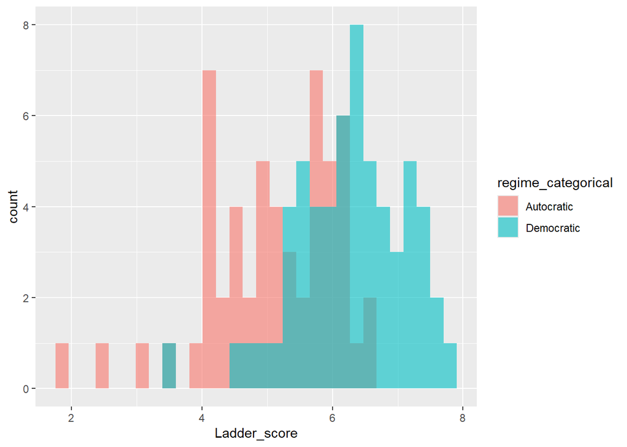

```r
ggplot(whr_vdem %>%
         drop_na(regime_categorical)) +
  geom_histogram(aes(x = Ladder_score,
                     fill = regime_categorical),
                 position = "identity",
                 alpha = 0.6)
```

Now, let’s calculate averages for Democracies and Autocracies.

```r
dem_avg = whr_vdem %>%
  filter(regime_categorical == "Democratic") %>% # leave only Democratic regimes
  summarize(mean = mean(Ladder_score))           # calculate the average

aut_avg = whr_vdem %>%
  filter(regime_categorical == "Autocratic") %>%
  summarize(mean = mean(Ladder_score))
```

And add the averages to the plot. So, are these groups different?

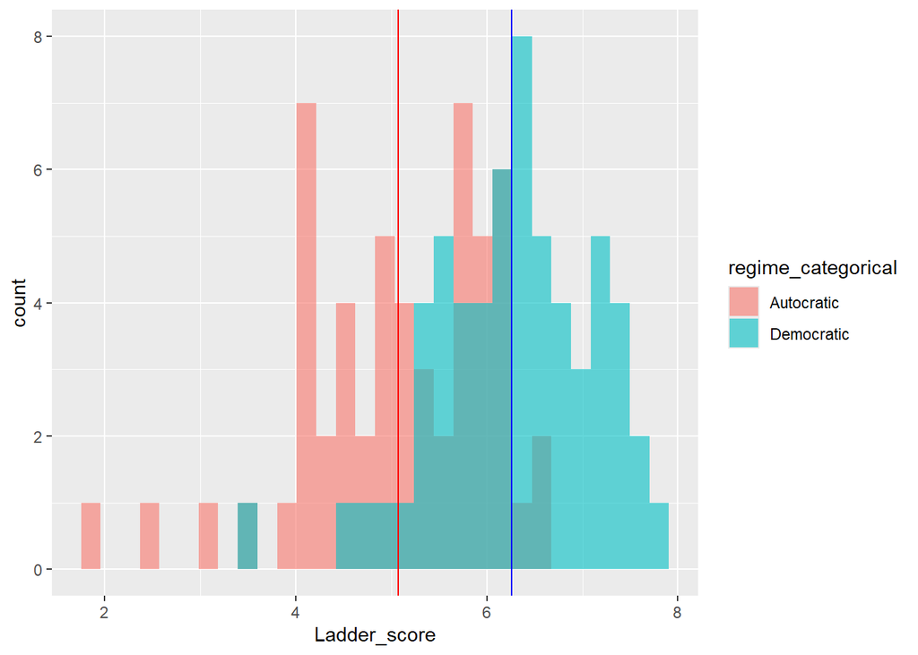

```r
ggplot(whr_vdem %>%
         drop_na(regime_categorical)) +
  geom_histogram(aes(x = Ladder_score, fill = regime_categorical),
                 position = "identity",
                 alpha = 0.6) +
  geom_vline(xintercept = dem_avg$mean, color = "blue") +
  geom_vline(xintercept = aut_avg$mean, color = "red")
```

Formally, we can compare it using statistical tests. What does p-value indicate?

```r
t.test(whr_vdem$Ladder_score ~ whr_vdem$regime_categorical)
```

```
    Welch Two Sample t-test

data:  whr_vdem$Ladder_score by whr_vdem$regime_categorical
t = -6.7424, df = 105.46, p-value = 8.575e-10
alternative hypothesis: true difference in means between group Autocratic and group Democratic is not equal to 0
95 percent confidence interval:
 -1.5392830 -0.8396989
sample estimates:
mean in group Autocratic mean in group Democratic
                5.074309                 6.263800
```

# Check List

- I know how to use `mutate()` and `case_when()` to recode my variables
- I have the intuition behind merging the data, and `left_join()` helps me doing complex stuff
- I know how to visualize multiple distributions
- I can easily compare distributions using `t.test()` and interpret the result

# Optional Exercises

First of all, recreate `whr_vdem` dataframe to have `Continent` variable in it. Use `left_join()` to create a dataset. Select the following variables: `Country_name`, `Ladder_score`, `Continent`

**Solution**

```r
whr_vdem = ... %>%
  ...() %>%
  select(Country_name, Ladder_score, Continent)
```

In `whr_vdem` dataframe create a variable `Continent_binary` using `mutate()` and `case_when()` on `Continent` to divide observation on `North America` and `Other`.

**Solution**

```r
whr_vdem = whr_vdem ...
  ...(Continent_binary = case_when(Continent == "North America" ... =  "...",
                                      Continent != "..." ~ "Other"))
```

Visualize the distributions of happiness score (`Ladder_score`). Is it helpful?

**Solution**

```r
ggplot() +
  geom_histogram(data = whr_vdem, aes(x = ... , ... = Continent_binary),
                 position = ...,
                 alpha = 0.6)
```

Calculate and add a a median for “Other” continents to the plot. Customize the plot, add `theme_bw()` and a title!

**Solution**

```r
other_avg = whr_vdem %>%
  filter(Continent == "...") ...
  ...(median = median(Ladder_score))

ggplot() +
  ...(..., aes(x = Ladder_score, fill = Continent_binary),
                 position = "identity",
                 alpha = ...) +
  geom_vline(... = )
```

Perform a `t.test()` to understand if the average Happiness between North America and Other continents are statistically different. Interpret the result

**Solution**

```r
...
```